# HW1_2025

**What is the alpha diversity of this site?** The figure shows a site; the species within the site are represented by letters (e.g., “a”, “b”, “c”). *Alpha diversity is species richness, or in other words the count of species present.* **Input an integer (whole number).**

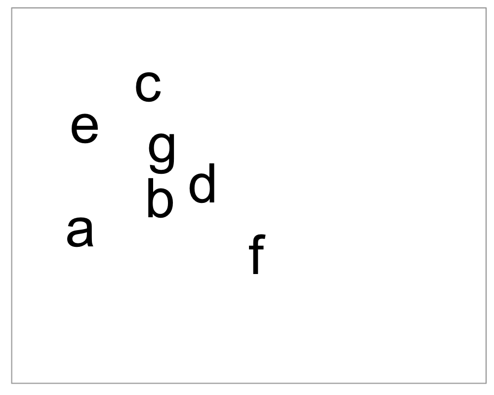

There are **7** species, represented by the letters a, b, c, d, e, f, g

**What is the alpha diversity of this site?** The figure shows a site; the species within the site are represented by letters (e.g., “a”, “b”, “c”). *Alpha diversity is species richness, or in other words the count of species present.* **Input an integer (whole number).**

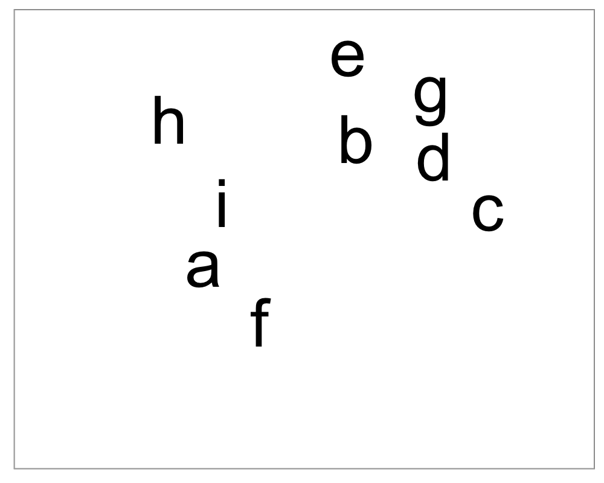

There are **9** species, represented by the letters a, b, c, d, e, f, g, h, i

**What is the alpha diversity of this site?** The figure shows a site; the species within the site are represented by letters (e.g., “a”, “b”, “c”). *Alpha diversity is species richness, or in other words the count of species present.* **Input an integer (whole number).**

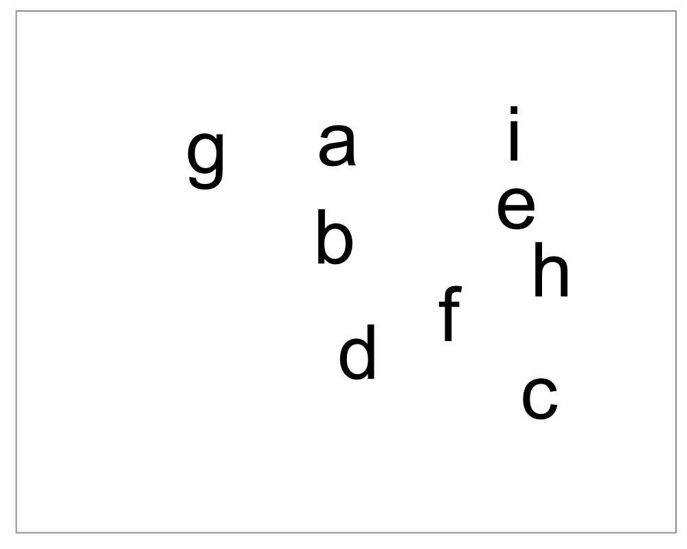

There are **9** species, represented by the letters a, b, c, d, e, f, g, h, i

**Which site or sites have the highest alpha diversity (species richness)?** The figure shows three sites representing three distinct ecological communities in a region. The species within the sites are represented by letters (e.g., “a”, “b”, “c”). Note: the letters within the title of a site (“site 1”) do not represent species. **Select *all* of the sites with the maximum alpha diversity;** it may be just one site, or it may be two or more.

site 1site 2site 3

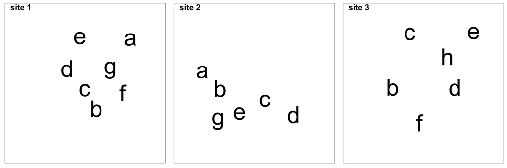

There is a maximum of **7** species, found in **site 1**

**Which site or sites have the highest alpha diversity (species richness)?** The figure shows three sites representing three distinct ecological communities in a region. The species within the sites are represented by letters (e.g., “a”, “b”, “c”). Note: the letters within the title of a site (“site 1”) do not represent species. **Select *all* of the sites with the maximum alpha diversity;** it may be just one site, or it may be two or more.

site 1site 2site 3

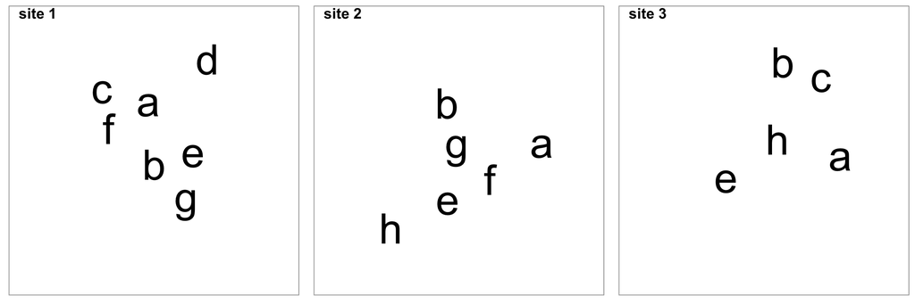

There is a maximum of **7** species, found in **site 1**

**Which site or sites have the highest alpha diversity (species richness)?** The figure shows three sites representing three distinct ecological communities in a region. The species within the sites are represented by letters (e.g., “a”, “b”, “c”). Note: the letters within the title of a site (“site 1”) do not represent species. **Select *all* of the sites with the maximum alpha diversity;** it may be just one site, or it may be two or more.

site 1site 2site 3

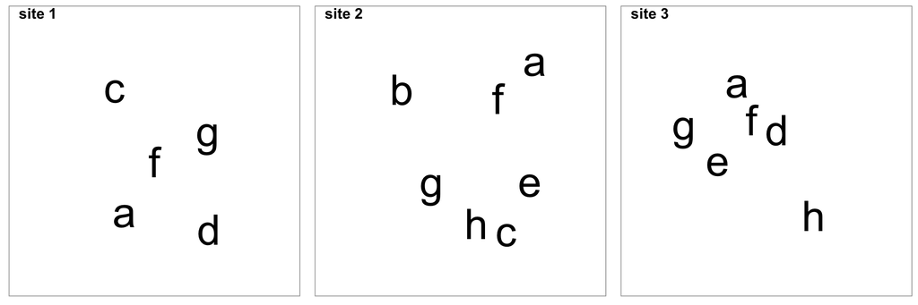

There is a maximum of **7** species, found in **site 2**

**What is the highest alpha diversity (species richness) in any site below?** The figure shows three sites representing three distinct ecological communities in a region. The species within the sites are represented by letters (e.g., “a”, “b”, “c”). Note: the letters within the title of a site (“site 1”) do not represent species. Remember, the alpha diversity is just the count of species present. Two or more sites may have the same (and highest) alpha diversity. **Input an integer** (whole number).

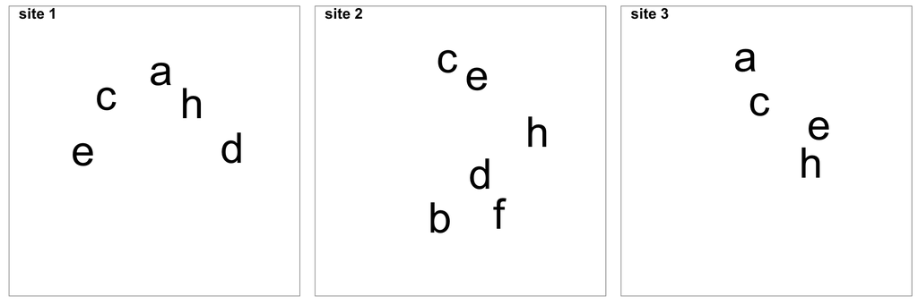

There is a maximum of **6** species, found in site 2

**What is the highest alpha diversity (species richness) in any site below?** The figure shows three sites representing three distinct ecological communities in a region. The species within the sites are represented by letters (e.g., “a”, “b”, “c”). Note: the letters within the title of a site (“site 1”) do not represent species. Remember, the alpha diversity is just the count of species present. Two or more sites may have the same (and highest) alpha diversity. **Input an integer** (whole number).

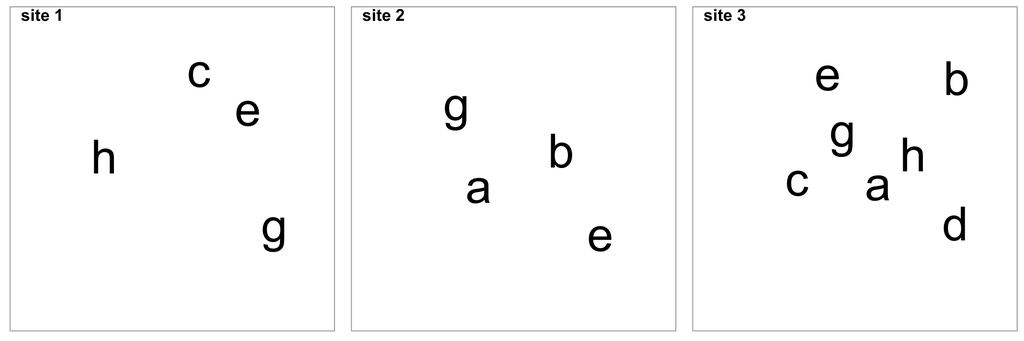

There is a maximum of **7** species, found in site 3

**What is the highest alpha diversity (species richness) in any site below?** The figure shows three sites representing three distinct ecological communities in a region. The species within the sites are represented by letters (e.g., “a”, “b”, “c”). Note: the letters within the title of a site (“site 1”) do not represent species. Remember, the alpha diversity is just the count of species present. Two or more sites may have the same (and highest) alpha diversity. **Input an integer** (whole number).

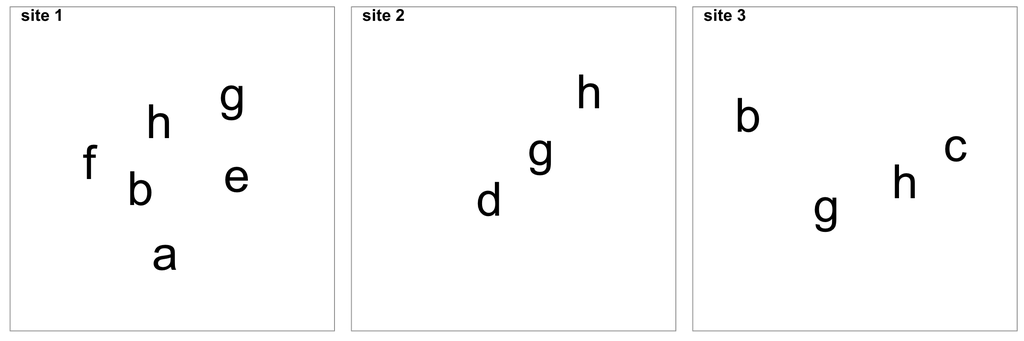

There is a maximum of **6** species, found in site 1

**Calculate the *average* alpha diversity between these two sites.** We are defining “average” as the arithmetic mean, or the sum of the species richness of *each* of the two sites, divided by the number of sites (in this case, two). If we represent the species richness in site 1 as $S_1$ and site 2 as $S_2$, then in the case of two sites, we can calculate the mean with $(S_1 + S_2) ÷ 2$. Remember that the *sum* of the species richness is *not* the count of how many species there are between the two sites. It’s the count of species in one site, plus the count of species in the other site---even if some species are shared. **Input a numeric value;** round to one digit. In some instances you may get a whole number, if so just include $.0$.

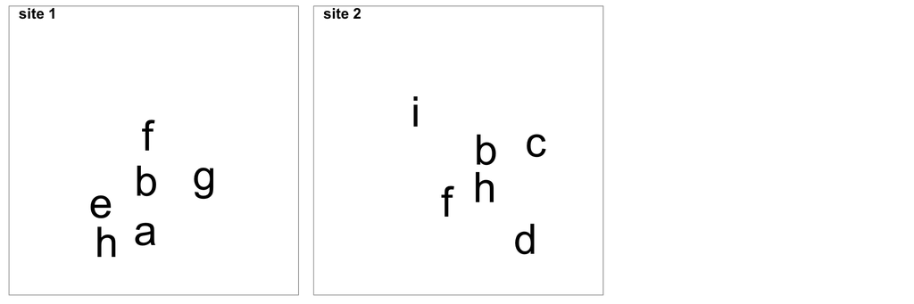

The average species richness is **6** species. There are 6 species in site 1, and 6 in site 2, so the formula is $(6 + 6) ÷ 2 = 12 ÷ 2 = 6$.

**Calculate the *average* alpha diversity between these two sites.** We are defining “average” as the arithmetic mean, or the sum of the species richness of *each* of the two sites, divided by the number of sites (in this case, two). If we represent the species richness in site 1 as $S_1$ and site 2 as $S_2$, then in the case of two sites, we can calculate the mean with $(S_1 + S_2) ÷ 2$. Remember that the *sum* of the species richness is *not* the count of how many species there are between the two sites. It’s the count of species in one site, plus the count of species in the other site---even if some species are shared. **Input a numeric value;** round to one digit. In some instances you may get a whole number, if so just include $.0$.

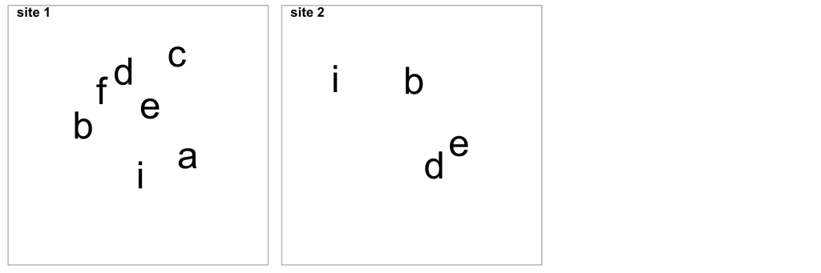

The average species richness is **5.5** species. There are 7 species in site 1, and 4 in site 2, so the formula is $(7 + 4) ÷ 2 = 11 ÷ 2 = 5.5$.

**Calculate the *average* alpha diversity between these two sites.** We are defining “average” as the arithmetic mean, or the sum of the species richness of *each* of the two sites, divided by the number of sites (in this case, two). If we represent the species richness in site 1 as $S_1$ and site 2 as $S_2$, then in the case of two sites, we can calculate the mean with $(S_1 + S_2) ÷ 2$. Remember that the *sum* of the species richness is *not* the count of how many species there are between the two sites. It’s the count of species in one site, plus the count of species in the other site---even if some species are shared. **Input a numeric value;** round to one digit. In some instances you may get a whole number, if so just include $.0$.

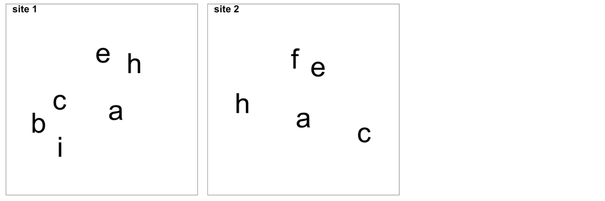

The average species richness is **5.5** species. There are 6 species in site 1, and 5 in site 2, so the formula is $(6 + 5) ÷ 2 = 11 ÷ 2 = 5.5$.

**Calculate the gamma diversity of these two sites.** Gamma diversity is the total species richness across the two sites. If a species is shared across the two sites, it should be counted once, but *not* counted separately for each site. Input an integer (whole number).

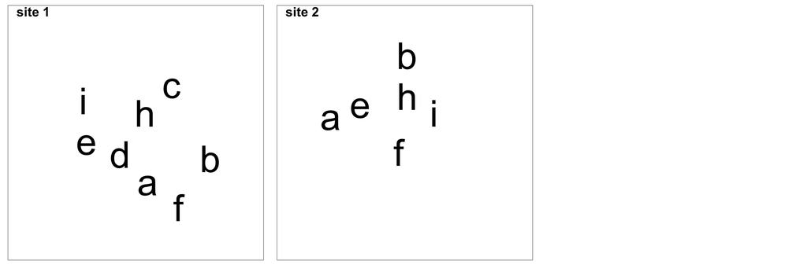

The species present across both sites are:

a, b, c, d, e, f, h, i

there are thus **8** total species present across the sites, which is the gamma diversity

**Calculate the gamma diversity of these two sites.** Gamma diversity is the total species richness across the two sites. If a species is shared across the two sites, it should be counted once, but *not* counted separately for each site. Input an integer (whole number).

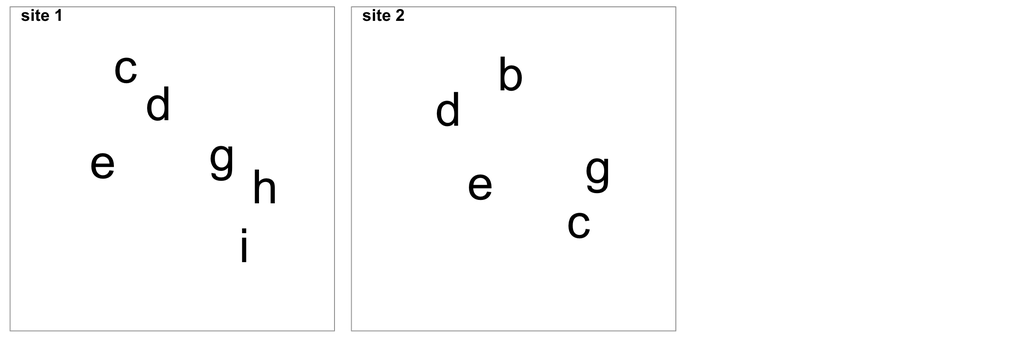

The species present across both sites are:

b, c, d, e, g, h, i

there are thus **7** total species present across the sites, which is the gamma diversity

**Calculate the gamma diversity of these two sites.** Gamma diversity is the total species richness across the two sites. If a species is shared across the two sites, it should be counted once, but *not* counted separately for each site. Input an integer (whole number).

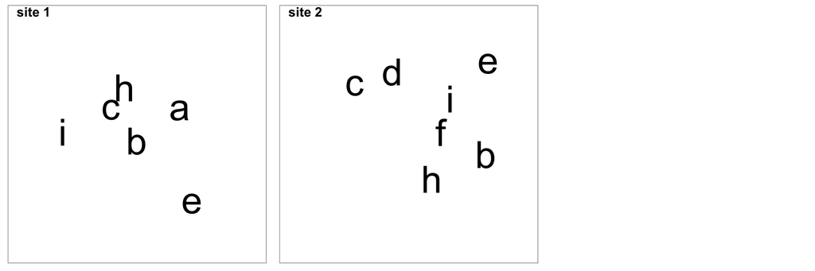

The species present across both sites are:

a, b, c, d, e, f, h, i

there are thus **8** total species present across the sites, which is the gamma diversity

**Calculate the gamma diversity of these four sites.** Gamma diversity is the total species richness across the four sites. If a species is shared across more than one site, it should be counted once, but *not* counted separately for each site. Input an integer (whole number).

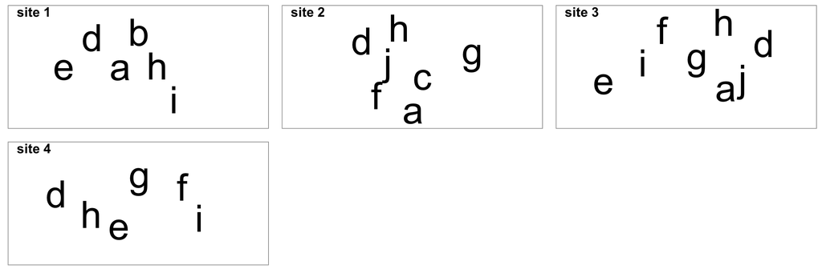

The species present across all of the sites are:

a, b, c, d, e, f, g, h, i, j

there are thus **10** total species present across the sites, which is the same as the gamma diversity

**Calculate the gamma diversity of these four sites.** Gamma diversity is the total species richness across the four sites. If a species is shared across more than one site, it should be counted once, but *not* counted separately for each site. Input an integer (whole number).

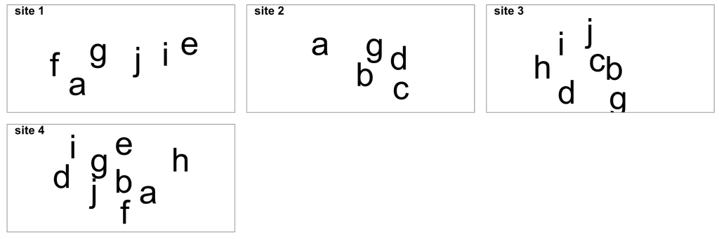

The species present across all of the sites are:

a, b, c, d, e, f, g, h, i, j

there are thus **10** total species present across the sites, which is the same as the gamma diversity

**Calculate the gamma diversity of these four sites.** Gamma diversity is the total species richness across the four sites. If a species is shared across more than one site, it should be counted once, but *not* counted separately for each site. Input an integer (whole number).

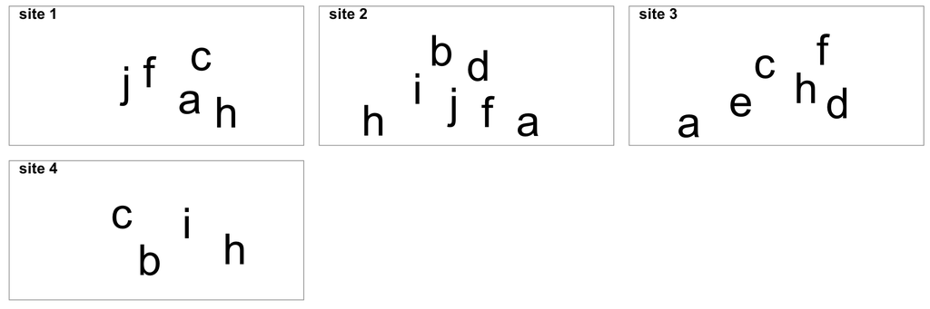

The species present across all of the sites are:

a, b, c, d, e, f, h, i, j

there are thus **9** total species present across the sites, which is the same as the gamma diversity

**Calculate the beta diversity of these two sites.** Beta diversity is defined as: beta = gamma ÷ mean(alpha). **Input a numeric value** rounded to two digits.

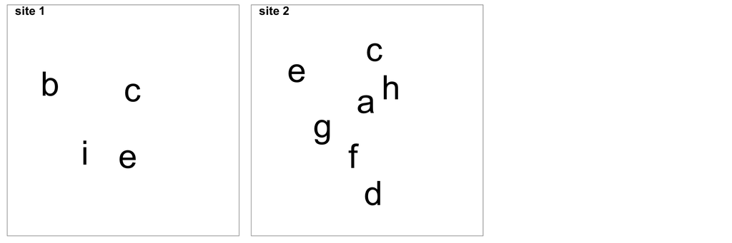

The species present across both sites are:

a, b, c, d, e, f, g, h, i

thus, the gamma diversity ($\gamma$) = **9**, the total species present across the sites.

The mean alpha ($\alpha$) diversity is the average species richness = **5.5**. There are 4 species in site 1, and 7 in site 2, so the formula is $(4 + 7) ÷ 2 = 11 ÷ 2 = 5.5$.

the **beta ($\beta$) diversity** is found via $\beta = \gamma ÷ \text{mean}(\alpha)$. In this case, that's $\beta = 9 ÷ 5.5 = 1.6363636$. Rounded to two (or fewer) digits, **beta = 1.64**

**Calculate the beta diversity of these two sites.** Beta diversity is defined as: beta = gamma ÷ mean(alpha). **Input a numeric value** rounded to two digits.

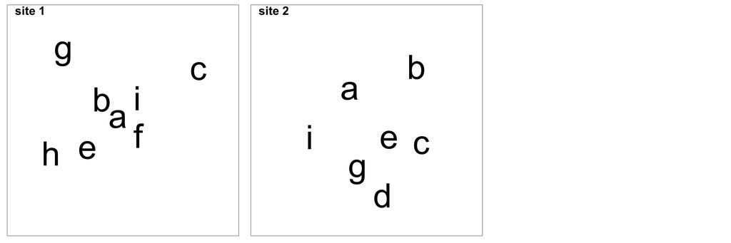

The species present across both sites are:

a, b, c, d, e, f, g, h, i

thus, the gamma diversity ($\gamma$) = **9**, the total species present across the sites.

The mean alpha ($\alpha$) diversity is the average species richness = **7.5**. There are 8 species in site 1, and 7 in site 2, so the formula is $(8 + 7) ÷ 2 = 15 ÷ 2 = 7.5$.

the **beta ($\beta$) diversity** is found via $\beta = \gamma ÷ \text{mean}(\alpha)$. In this case, that's $\beta = 9 ÷ 7.5 = 1.2$. Rounded to two (or fewer) digits, **beta = 1.2**

**Calculate the beta diversity of these two sites.** Beta diversity is defined as: beta = gamma ÷ mean(alpha). **Input a numeric value** rounded to two digits.

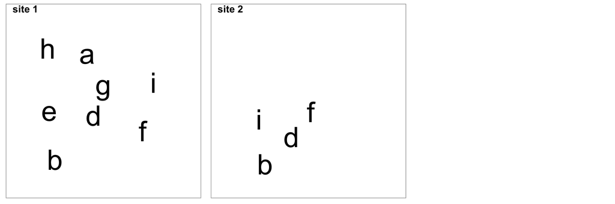

The species present across both sites are:

a, b, d, e, f, g, h, i

thus, the gamma diversity ($\gamma$) = **8**, the total species present across the sites.

The mean alpha ($\alpha$) diversity is the average species richness = **6**. There are 8 species in site 1, and 4 in site 2, so the formula is $(8 + 4) ÷ 2 = 12 ÷ 2 = 6$.

the **beta ($\beta$) diversity** is found via $\beta = \gamma ÷ \text{mean}(\alpha)$. In this case, that's $\beta = 8 ÷ 6 = 1.3333333$. Rounded to two (or fewer) digits, **beta = 1.33**

**Calculate the beta diversity of these four sites.** Beta diversity is defined as: beta = gamma ÷ mean(alpha). **Input a numeric value** rounded to two or fewer digits.

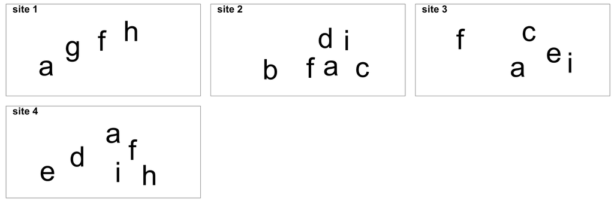

The species present across all four sites are:

a, b, c, d, e, f, g, h, i

thus, the gamma diversity ($\gamma$) = **9**, the total species present across the sites.

the **beta ($\beta$) diversity** is found via $\beta = \gamma ÷ \text{mean}(\alpha)$. In this case, that's $\beta = 9 ÷ 5.25 = 1.7142857$. Rounded to two (or fewer) digits, **beta = 1.71**

**Calculate the beta diversity of these four sites.** Beta diversity is defined as: beta = gamma ÷ mean(alpha). **Input a numeric value** rounded to two or fewer digits.

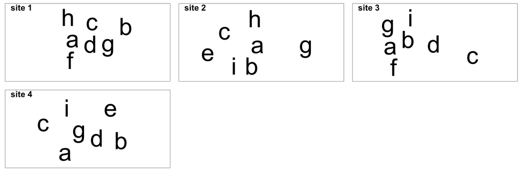

The species present across all four sites are:

a, b, c, d, e, f, g, h, i

thus, the gamma diversity ($\gamma$) = **9**, the total species present across the sites.

the **beta ($\beta$) diversity** is found via $\beta = \gamma ÷ \text{mean}(\alpha)$. In this case, that's $\beta = 9 ÷ 7 = 1.2857143$. Rounded to two (or fewer) digits, **beta = 1.29**

**Calculate the beta diversity of these four sites.** Beta diversity is defined as: beta = gamma ÷ mean(alpha). **Input a numeric value** rounded to two or fewer digits.

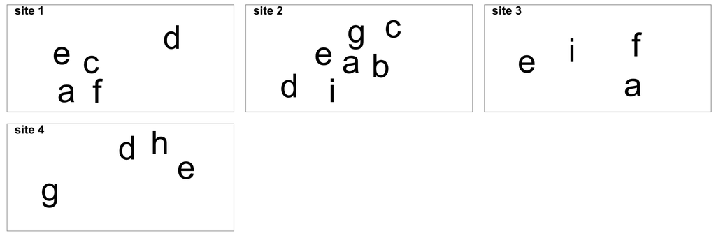

The species present across all four sites are:

a, b, c, d, e, f, g, h, i

thus, the gamma diversity ($\gamma$) = **9**, the total species present across the sites.

the **beta ($\beta$) diversity** is found via $\beta = \gamma ÷ \text{mean}(\alpha)$. In this case, that's $\beta = 9 ÷ 5 = 1.8$. Rounded to two (or fewer) digits, **beta = 1.8**

**Choose the three sites that together yield the highest gamma diversity.** This aligns with what many (but not all) conservation organizations would choose when purchasing land for a reserve strategy.

site 1site 2site 3site 4site 5site 6

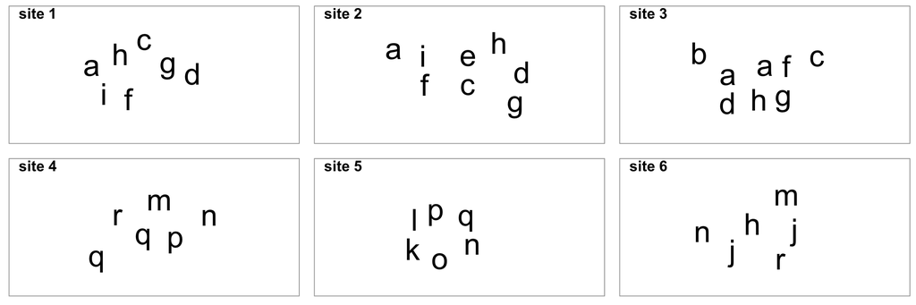

The three sites that together maximize gamma diversity are: **s2, s5, s6**.

Across these three sites, there are 17 species:

a, c, d, e, f, g, h, i, j, k, l, m, n, o, p, q, r

**Choose the three sites that together yield the highest gamma diversity.** This aligns with what many (but not all) conservation organizations would choose when purchasing land for a reserve strategy.

site 1site 2site 3site 4site 5site 6

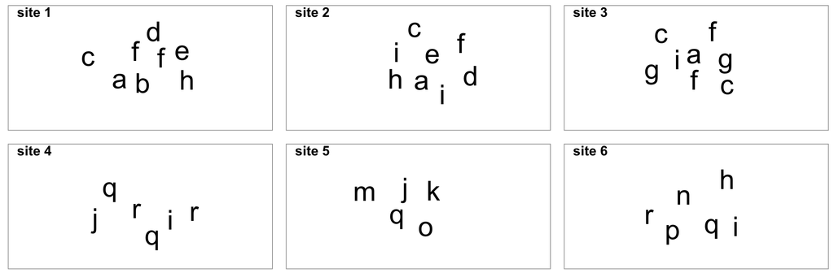

The three sites that together maximize gamma diversity are: **s1, s5, s6**.

Across these three sites, there are 16 species:

a, b, c, d, e, f, h, i, j, k, m, n, o, p, q, r

**Choose the three sites that together yield the highest gamma diversity.** This aligns with what many (but not all) conservation organizations would choose when purchasing land for a reserve strategy.

site 1site 2site 3site 4site 5site 6

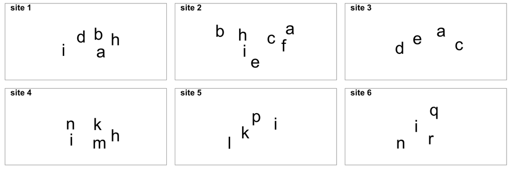

The three sites that together maximize gamma diversity are: **s2, s5, s6**.

Across these three sites, there are 13 species:

a, b, c, e, f, h, i, k, l, n, p, q, r

**Which pair or pairs (set of two sites) has the highest beta diversity?** Two or more sets of sites may share the highest beta diversity. In previous questions, you were calculating one shared (average) beta diversity across a set of sites. In this question, you should calculate beta diversity for *each* pair separately. That means you should calculate gamma diversity, and mean alpha diversity, only for each **pair** of sites, *not* for all of the sites together. *You may or may not have to calculate every combination to get the right answer.* To save time, you may be able to rule site pairs out that together have low gamma diversity and high species overlap. Remember that mathematically, we get high beta diversity when there is higher gamma diversity *and* lower mean alpha, which intuitively translates to high beta diversity when we have high total species richness across the two sites and few shared species between the two sites.

s1, s2s1, s3s1, s4s2, s3s2, s4s3, s4

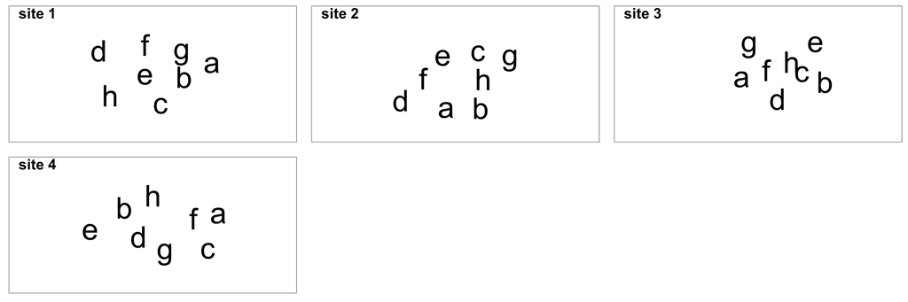

**Which pair or pairs (set of two sites) has the highest beta diversity?** Two or more sets of sites may share the highest beta diversity. In previous questions, you were calculating one shared (average) beta diversity across a set of sites. In this question, you should calculate beta diversity for *each* pair separately. That means you should calculate gamma diversity, and mean alpha diversity, only for each **pair** of sites, *not* for all of the sites together. *You may or may not have to calculate every combination to get the right answer.* To save time, you may be able to rule site pairs out that together have low gamma diversity and high species overlap. Remember that mathematically, we get high beta diversity when there is higher gamma diversity *and* lower mean alpha, which intuitively translates to high beta diversity when we have high total species richness across the two sites and few shared species between the two sites.

s1, s2s1, s3s1, s4s2, s3s2, s4s3, s4

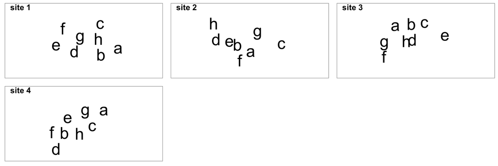

**Which pair or pairs (set of two sites) has the highest beta diversity?** Two or more sets of sites may share the highest beta diversity. In previous questions, you were calculating one shared (average) beta diversity across a set of sites. In this question, you should calculate beta diversity for *each* pair separately. That means you should calculate gamma diversity, and mean alpha diversity, only for each **pair** of sites, *not* for all of the sites together. *You may or may not have to calculate every combination to get the right answer.* To save time, you may be able to rule site pairs out that together have low gamma diversity and high species overlap. Remember that mathematically, we get high beta diversity when there is higher gamma diversity *and* lower mean alpha, which intuitively translates to high beta diversity when we have high total species richness across the two sites and few shared species between the two sites.

s1, s2s1, s3s1, s4s2, s3s2, s4s3, s4

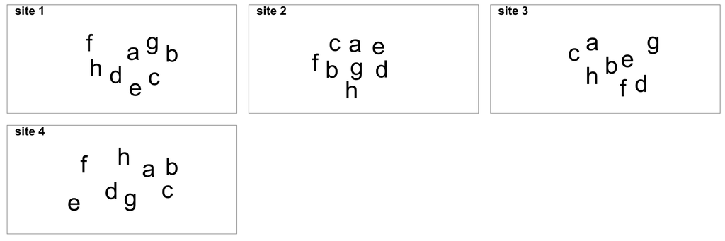